# R Markdown turtorial - SW Carpentry

Christoffer M. Kramer

21/10/2020

**This is bold**

*this is italics*

- and - can create lists
- this
- is
- A
- list

“1.” “2.” etc. creates numbered lists, you can also use the same number

1. this
2. is
3. a
4. list

“#” creates titles “##” creates subtitles etc. #Title ##Subtitle ###Subsubtitle

Use dollar sign for math equations $1+1 = 3 (or is it 2?)

For help with formatting look at “Markdown Qucik reference” under help

Always give code chunks a unique name

```r
library(ggplot2)
library(gapminder)

gapminder
```

```
## # A tibble: 1,704 x 6
##    country     continent  year lifeExp      pop gdpPercap
##    <fct>       <fct>     <int>   <dbl>    <int>     <dbl>
##  1 Afghanistan Asia       1952    28.8  8425333      779.
##  2 Afghanistan Asia       1957    30.3  9240934      821.
##  3 Afghanistan Asia       1962    32.0 10267083      853.
##  4 Afghanistan Asia       1967    34.0 11537966      836.
##  5 Afghanistan Asia       1972    36.1 13079460      740.
##  6 Afghanistan Asia       1977    38.4 14880372      786.
##  7 Afghanistan Asia       1982    39.9 12881816      978.
##  8 Afghanistan Asia       1987    40.8 13867957      852.
##  9 Afghanistan Asia       1992    41.7 16317921      649.
## 10 Afghanistan Asia       1997    41.8 22227415      635.
## # ... with 1,694 more rows
```

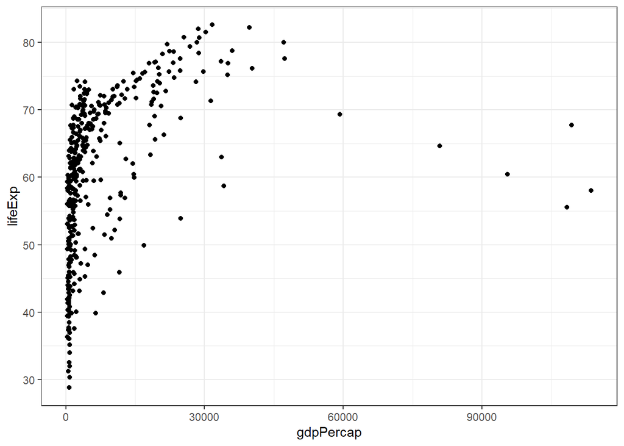

```r
theme_set(theme_bw())  # set theme to white background for better visibility
anim <- ggplot(subset(gapminder, continent == "Asia"), aes(gdpPercap, lifeExp)) +
  geom_point()

anim
```

You can change how chunks are displayed

- echo=FALSE to avoid having the code itself shown.
- Use results=“hide” to avoid having any results printed.
- Use eval=FALSE to have the code shown but not evaluated.
- Use warning=FALSE and message=FALSE to hide any warnings or messages produced.
- Use fig.height and fig.width to control the size of the figures produced (in inches).

use global_options to set options for alle code chunks below is a very small point graph

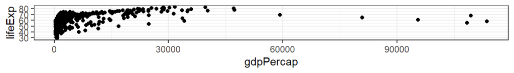

```r
anim
```

YOu can make inline codes, which replaces the code with the value of the result

2